# Red vs Blue

Angel Abdulnour

2023-08-21

# 1 What is UFC (Introduction)

UFC (Ultimate Fighting Championship) is an organization where fighters can compete against each other using MMA (Mixed Martial Arts) techniques for money, fame, glory, and any other reason one might have for stepping into the octagon. Two fighters, one designated red and the other blue, are set up against each other according to their weight class. There are, in general, 3 ways for a fighter to win the bout. K/O (Knockout), submission (opponent taps out), or decision (fighters both last until the end of the bout and winner is based off of the judges scorecards). Within each category are others like TKO, split decision, majority decision, and unanimous decision.

## 1.1 About the Model

This model’s goal is to take in variables such as both fighters’ height, age, average strikes, average takedowns etc, and try to determine who would be the winner. The reason this model is needed is for the accuracy of sports betting. Before the advent of data science fighting experts were the ones who determined which fighter was better and by how much. The arena then decides the betting odds based off of that. This leads to inaccurate odds and could cost the arena a lot of money over time. Nowadays that job is being left left to data science and is mainly relying on statistics and data. However, there is no perfect and even the multi million dollar organization, UFC, and other betting companies can predict wrong outcomes. This is why we continue to train and build better models, in hopes of gainning even one percent more accuracy which could lead to saving millions of dollars over time.

## 1.2 Project Roadmap

How will we progress throughout this project? The first step when dealing with any dataset is to look over and understand it. We can look over the codebook and understand what each of the columns represent and we can use our personal experience through watching UFC in order to make sense of it. Then we look further in and use data analysis to see some surface level trends as well be able to manipulate the data to our satisfaction. After the data is properly set we can then get to the creation of our recipe which will lead to the training of our models. At the end we will fit and test our best performing model and hopefully make millions betting against the multimillion dollar betting companies.

The data comes from the “ufc-master” data sheet found on Kaggle:

https://www.kaggle.com/datasets/mdabbert/ultimate-ufc-dataset?select=ufc-master.csv

# 2 Exploratory Data Analysis

In the codebook provided in the .txt file I explained all the variables I will use and are relevant to my models. However, the original dataset found on kaggle includes many excess variable that are useless to the model as well as many variables with a high colinearity.

## 2.1 Load and Analyze

To begin we load in the full dataset so that we can check out what we are working with.

| R_fighter | B_fighter | R_odds | B_odds | R_ev | B_ev | date | location | country | Winner | title_bout | weight_class | gender | no_of_rounds | B_current_lose_streak | B_current_win_streak | B_draw | B_avg_SIG_STR_landed | B_avg_SIG_STR_pct | B_avg_SUB_ATT | B_avg_TD_landed | B_avg_TD_pct | B_longest_win_streak | B_losses | B_total_rounds_fought | B_total_title_bouts | B_win_by_Decision_Majority | B_win_by_Decision_Split | B_win_by_Decision_Unanimous | B_win_by_KO.TKO | … |
| --- | --- | --- | --- | --- | --- | --- | --- | --- | --- | --- | --- | --- | --- | --- | --- | --- | --- | --- | --- | --- | --- | --- | --- | --- | --- | --- | --- | --- | --- | --- |
| Thiago Santos | Johnny Walker | -150 | 130 | 66.66667 | 130.00000 | 2021-10-02 | Las Vegas, Nevada, USA | USA | Red | False | Light Heavyweight | MALE | 5 | 0 | 1 | 0 | 3.42 | 0.59 | 0.7 | 0.24 | 1.00 | 4 | 2 | 11 | 0 | 0 | 0 | 1 | 4 | … |
| Alex Oliveira | Niko Price | 170 | -200 | 170.00000 | 50.00000 | 2021-10-02 | Las Vegas, Nevada, USA | USA | Blue | False | Welterweight | MALE | 3 | 2 | 0 | 0 | 5.16 | 0.42 | 0.8 | 0.79 | 0.22 | 2 | 5 | 24 | 0 | 0 | 0 | 0 | 4 | … |
| Misha Cirkunov | Krzysztof Jotko | 110 | -130 | 110.00000 | 76.92308 | 2021-10-02 | Las Vegas, Nevada, USA | USA | Blue | False | Middleweight | MALE | 3 | 1 | 0 | 0 | 2.92 | 0.41 | 0.1 | 1.15 | 0.34 | 5 | 5 | 38 | 0 | 0 | 2 | 6 | 1 | … |
| Alexander Hernandez | Mike Breeden | -675 | 475 | 14.81481 | 475.00000 | 2021-10-02 | Las Vegas, Nevada, USA | USA | Red | False | Lightweight | MALE | 3 | 1 | 0 | 0 | 4.04 | 0.34 | 0.0 | 0.00 | 0.00 | 0 | 1 | 3 | 0 | 0 | 0 | 0 | 0 | … |
| Joe Solecki | Jared Gordon | -135 | 115 | 74.07407 | 115.00000 | 2021-10-02 | Las Vegas, Nevada, USA | USA | Blue | False | Lightweight | MALE | 3 | 0 | 2 | 0 | 5.22 | 0.56 | 0.0 | 2.54 | 0.39 | 2 | 3 | 19 | 0 | 0 | 0 | 4 | 1 | … |
| Antonina Shevchenko | Casey O’Neill | 215 | -265 | 215.00000 | 37.73585 | 2021-10-02 | Las Vegas, Nevada, USA | USA | Blue | False | Women’s Flyweight | FEMALE | 3 | 0 | 2 | 0 | 5.48 | 0.56 | 1.4 | 3.83 | 0.50 | 2 | 0 | 5 | 0 | 0 | 0 | 0 | 1 | … |
| Bethe Correia | Karol Rosa | 500 | -720 | 500.00000 | 13.88889 | 2021-10-02 | Las Vegas, Nevada, USA | USA | Blue | False | Women’s Bantamweight | FEMALE | 3 | 0 | 3 | 0 | 7.88 | 0.54 | 0.0 | 1.50 | 0.50 | 3 | 0 | 9 | 0 | 0 | 1 | 2 | 0 | … |
| Devonte Smith | Jamie Mullarkey | -155 | 135 | 64.51613 | 135.00000 | 2021-10-02 | Las Vegas, Nevada, USA | USA | Blue | False | Lightweight | MALE | 3 | 0 | 1 | 0 | 3.03 | 0.40 | 0.4 | 3.50 | 0.32 | 1 | 2 | 7 | 0 | 0 | 0 | 0 | 1 | … |
| Douglas Silva de Andrade | Gaetano Pirrello | -280 | 225 | 35.71429 | 225.00000 | 2021-10-02 | Las Vegas, Nevada, USA | USA | Red | False | Bantamweight | MALE | 3 | 1 | 0 | 0 | 0.99 | 0.55 | 0.0 | 0.00 | 0.00 | 0 | 1 | 2 | 0 | 0 | 0 | 0 | 0 | … |
| Stephanie Egger | Shanna Young | -155 | 135 | 64.51613 | 135.00000 | 2021-10-02 | Las Vegas, Nevada, USA | USA | Red | False | Women’s Bantamweight | FEMALE | 3 | 2 | 0 | 0 | 3.04 | 0.53 | 1.0 | 0.00 | 0.00 | 0 | 2 | 5 | 0 | 0 | 0 | 0 | 0 | … |

```
## [1] 4896  119
```

Right off the bat we see several of the variables that I will not be using such as the names of the fighters. We also notice that there are 4896 observations and 119 total variables. Let’s clean this up. We use our personal knowledge and experience of UFC to get rid of many variables such as the names of the fighters, which logically have no impact on who the winner would be.

## 2.2 Getting our Main Dataset

```r
UFC_Main <- UFC_Original[, c(3, 4, 10, 13:25, 27:31, 33:36, 38:48, 50:54, 56:59, 61, 62, 78, 108, 109, 111, 70:77)]

#include 12 if you want weight class
```

Here we created a subset of the original dataset that only includes the variables that we are interested in (which are listed in the codebook). Now that we have “trimmed the fat off” lets get some general information about our dataset and our relevant variables.

## 2.3 Dataset Analysis and Visual Data

```r
dim(UFC_Main)
```

```
## [1] 4896   59
```

```r
sum(is.na(UFC_Main)) #less than 3 percent of data is missing
```

```
## [1] 6718
```

We can see that our trimmed dataset has a total of 288,864 cells and 6718 of them are null. This is a fairly good number because it means that less than 3 percent of dataset has null values, which is a number we could afford considering the size of our data. Rather than simply removing it, lets analyze this null data and see if we could come to any conclusions based off the lack of data.

### 2.3.1 Null data

```
##               R_odds B_avg_SIG_STR_landed    B_avg_SIG_STR_pct
##           0.02042484          18.99509804          15.62500000
##        B_avg_SUB_ATT      B_avg_TD_landed         B_avg_TD_pct
##          16.99346405          17.01388889          17.19771242
## R_avg_SIG_STR_landed    R_avg_SIG_STR_pct        R_avg_SUB_ATT
##           9.29330065           7.29166667           7.29166667
##      R_avg_TD_landed         R_avg_TD_pct         finish_round
##           7.29166667           7.49591503          12.70424837
```

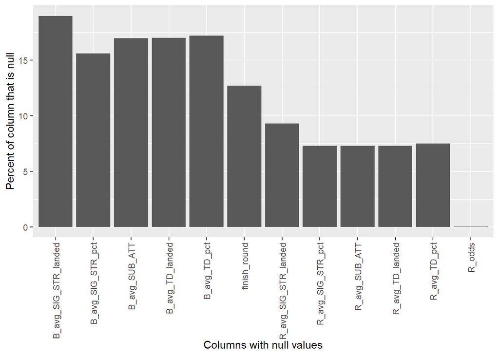

#### 2.3.1.1 Fix Null Values for Continued Analysis

```r
nullValues <- apply(UFC_Main, 1, function(x) sum(is.na(x)))

filteredUFC <- UFC_Main[nullValues < 10, ]
sum(is.na(filteredUFC))
```

```
## [1] 4334
```

Before, we had 6718 total null values, now we have 4334 which means we dropped the number of null values by around 1/3 by getting rid of any fights that have 10 or more missing values. In a dataset with around 50 predictors 10 null values means that around 20% of the information from the fight was not recorded. Since we have around 5,000 observations we can afford to be a bit more picky.

```r
# Impute missing values
UFC_NoNull <- filteredUFC %>%
  mutate(across(where(is.numeric), ~ ifelse(is.na(.), mean(., na.rm = TRUE), .)),
         across(where(is.factor), ~ ifelse(is.na(.), as.factor(get_mode(.)), .)))


sum(is.na(UFC_NoNull))
```

```
## [1] 0
```

To get rid of the remaining null values I simply filled them in with the mean of each column for numerical predictors and the mode is applied for categorical ones. Luckily there were no null values for categorical columns. Now we can continue to analyze the data like this.

### 2.3.2 Variable Correlations

```
##                             Var1                        Var2       Freq
## 54                        R_odds                      B_odds -0.9703909
## 1021       B_total_rounds_fought                      B_wins  0.9306947
## 2160                R_Height_cms                 R_Reach_cms  0.8988515
## 1134                B_Height_cms                 B_Reach_cms  0.8721955
## 702                     B_losses       B_total_rounds_fought  0.8587109
## 1019        B_longest_win_streak                      B_wins  0.8574487
## 2047       R_total_rounds_fought                      R_wins  0.8570450
## 2045        R_longest_win_streak                      R_wins  0.8219696
## 862        B_total_rounds_fought B_win_by_Decision_Unanimous  0.8012584
## 1024 B_win_by_Decision_Unanimous                      B_wins  0.7674421
## 1728                    R_losses       R_total_rounds_fought  0.7662496
## 1025             B_win_by_KO.TKO                      B_wins  0.7635022
## 2050 R_win_by_Decision_Unanimous                      R_wins  0.7504404
## 2088                B_Height_cms                R_Height_cms  0.7452045
```

[output cut: 32 more lines]

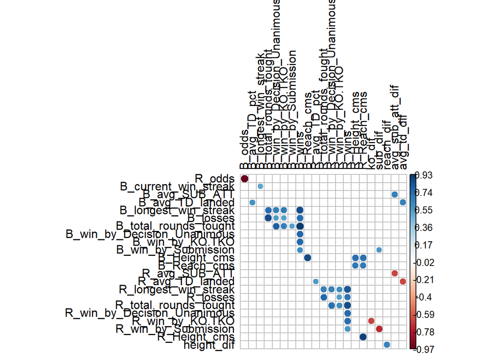

### 2.3.3 Response Variable

Before we split the data let us take a look at the distribution of our response variable.

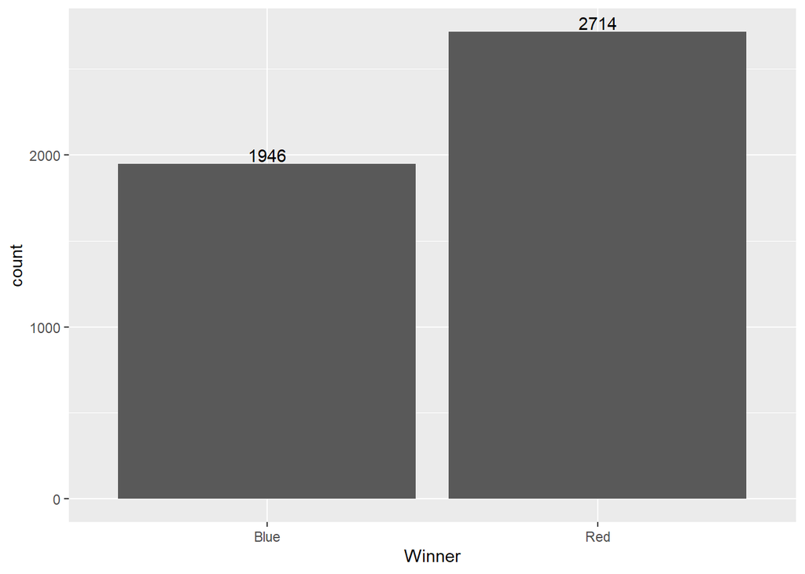

```r
ggplot(UFC_NoNull, aes(x = Winner)) +
  geom_bar() +
  geom_text(aes(label=..count..),stat='count',position=position_dodge(0.9),vjust=-0.2)
```

### 2.3.4 Categorical variables

The final part of our EDA is determining which variables are categorical. We see here that we have 6 total categorical variables, including the response variable.

```r
character_Vars <- UFC_NoNull %>% select_if(where(function(col) is.factor(col) | is.character(col) )) %>% names()
character_Vars
```

```
## [1] "Winner"      "gender"      "B_Stance"    "R_Stance"    "better_rank"
## [6] "finish"
```

This now concludes our data analysis and we begin to work with the model

# 3 Training

## 3.1 Data Split

The first thing that must be done is to split the dataset into two, the training set and the test set. We use stratified sampling to split the training and testing sets which will help ensure that the “Winner” variable is more evenly split between the two. I decided to do a 75/25 split which gives us a little more room for the training set.

```r
set.seed(1)
UFC_Split <- initial_split(UFC_Main, strata = "Winner")

UFC_Train <- training(UFC_Split)
UFC_Test <- testing(UFC_Split)

dim(UFC_Train)
```

```
## [1] 3671   59
```

```r
dim(UFC_Test)
```

```
## [1] 1225   59
```

## 3.2 Stratification

We see below that our stratified sampling did work and we have a roughly even distribution of red and blue winners between the Main dataset, test set, and the training set.

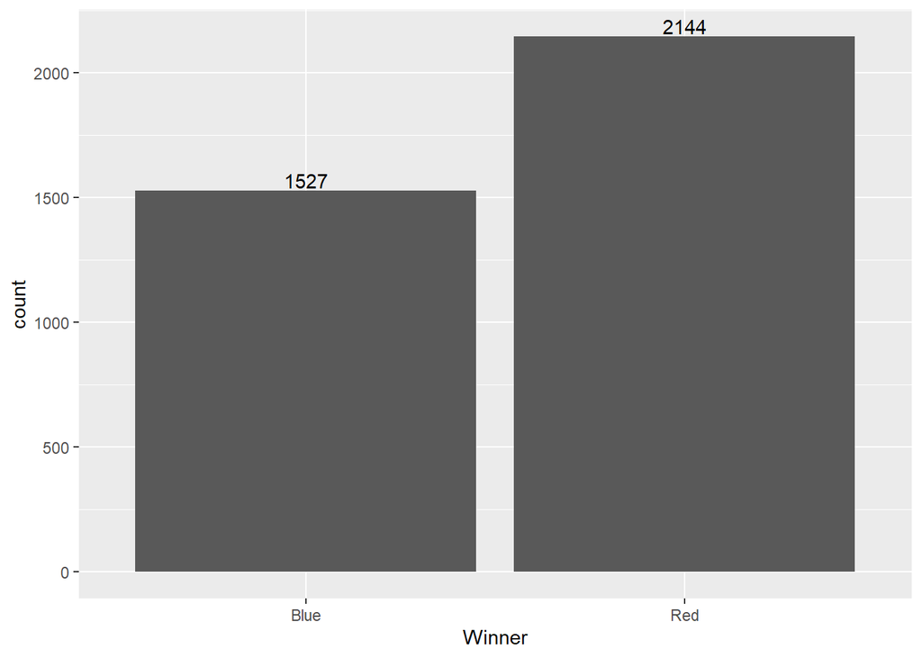

```r
ggplot(UFC_Train, aes(x = Winner)) +
  geom_bar() +
  geom_text(aes(label=..count..),stat='count',position=position_dodge(0.9),vjust=-0.2)
```

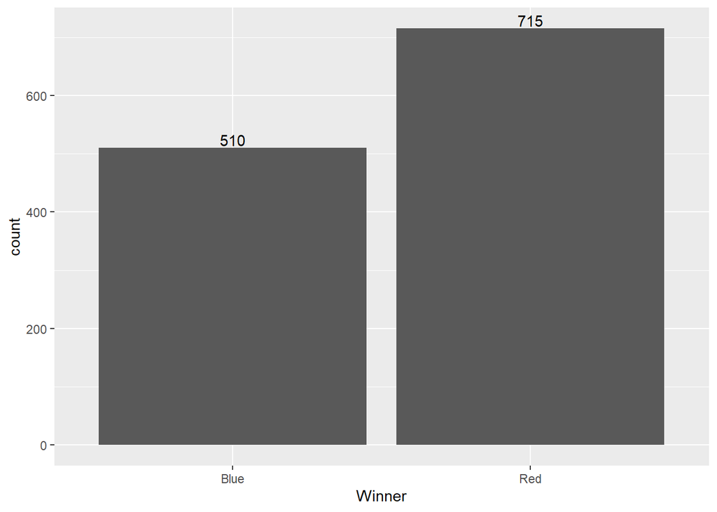

```r
ggplot(UFC_Test, aes(x = Winner)) +
  geom_bar() +
  geom_text(aes(label=..count..),stat='count',position=position_dodge(0.9),vjust=-0.2)
```

## K-fold Cross Validation

The reason I gave the training set 75 percent of the original data, as opposed to just 70, was so we could leave some extra room for validation. The type of validation we will use is k-fold cross validation which splits the training data into 5 folds. The model then trains on 4 of the folds and tests on the fifth until each of the five folds has been tested on. The average results of the all five tests are then dsiplayed. We use this method to ensure there is more consistency when we choose our model to finally test.

```r
UFC_Folds <- vfold_cv(UFC_Train, v = 5, strata = "Winner")
```

## 3.3 Recipe creation

Next we will create the recipe that we will use for our models

```r
numeric_predictors <- names(UFC_Train) %>%
  keep(~ is.numeric(UFC_Train[[.]]))

categorical_predictors <- names(UFC_Train) %>%
  keep(~ is.factor(UFC_Train[[.]]) | is.character(UFC_Train[[.]]))

UFC_Recipe <- recipe(Winner ~ ., data = UFC_Train) %>%


  step_impute_linear(numeric_predictors) %>%
#  step_impute_mode(categorical_predictors) %>%

  step_dummy(gender, B_Stance, R_Stance, better_rank, finish) %>%
  step_interact(~ R_odds:B_odds) %>%
  step_interact(~ B_total_rounds_fought:B_wins) %>%
  step_center(all_predictors()) %>%
  step_scale(all_predictors())
```

# 4 Modelling

## 4.1 Binary Logistic Classification

To start we will start with a more simple model for classification. The logistic model. This is the classification version of linear regression. The model can be uderstood by imagining an S-curve plot between 0 and 1. The point on the curve can be understood as the probability of the predicted outcome where 1 is interpreted as yes and 0 is no.

```r
UFC_Logistic_Spec <- logistic_reg(penalty = tune(), mixture = tune()) %>%
  set_engine("glmnet") %>%
  set_mode("classification")

UFC_Logistic_Workflow <- workflow() %>%
  add_model(UFC_Logistic_Spec) %>%
  add_recipe(UFC_Recipe)

UFC_Logistic_Tune <- grid_regular(
  penalty(range = c(0.001, 1)),
  mixture(range = c(0.05, 1)),
  levels = 5
)
```

```r
UFC_Logistic_Fit <- tune_grid(
  UFC_Logistic_Workflow,
  resamples = UFC_Folds,
  grid = UFC_Logistic_Tune,
)
save(UFC_Logistic_Fit, file = "UFC_Logistic_Fit.rda")
#Best parameters are Penalty = 1.781353 and Mixture = 0.05
```

For the logistic model we tuned two parameters, penalty and mixture. We set the tuning grid to have 5 levels for each parameter in order for us to be able to find the better parameters for this model.

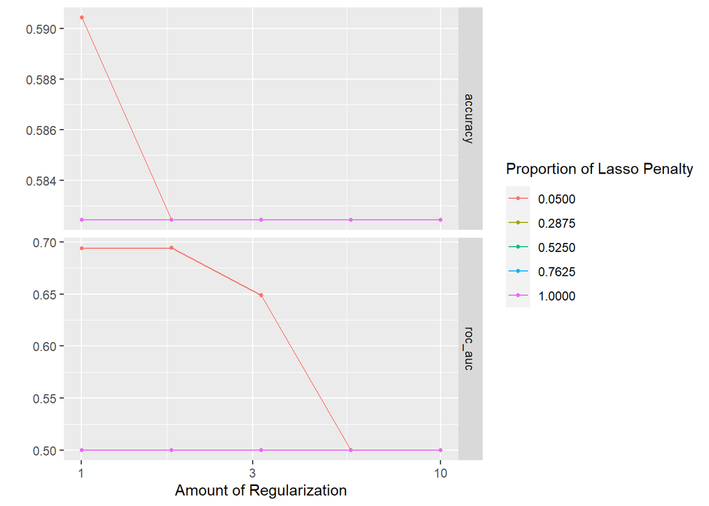

```r
load("UFC_Logistic_Fit.rda")
autoplot(UFC_Logistic_Fit)
```

## 4.2 Support Vector Machine

The next model we will use is the support vector machine model which is supposed to be used on binary classification models. In our case our two choices are red and blue which qualifies us to use this model. A Support Vector Machine (SVM for short) works by creating a hyperplane that separates our binary choices and decides that one side will be red and hte other will be blue. It then bases its prediction of whether the outcome is red or blue based on what side of the hyperplane it lands on.

```r
UFC_SVM_Spec <- svm_rbf(cost = tune(), rbf_sigma = tune()) %>%
  set_engine("kernlab") %>%
  set_mode("classification")

UFC_SVM_Workflow <- workflow() %>%
  add_model(UFC_SVM_Spec) %>%
  add_recipe(UFC_Recipe)

UFC_SVM_Tune <- grid_regular(
  cost(range = c(0.1, 10)),
  rbf_sigma(range = c(0.1, 1)),
  levels = 5
)
```

```r
UFC_SVM_Fit <- tune_grid(
  UFC_SVM_Workflow,
  resamples = UFC_Folds,
  grid = UFC_SVM_Tune,
)
save(UFC_SVM_Fit, file = "UFC_SVM_Fit.rda")
#The best parameters are cost = 1.071773 and rbf_sigma = 1.258925 with mean AUC of 0.50848
```

In this model the two parameters we tuned were cost and rbf_sigma. Once again the tuning grid is set to five levels.

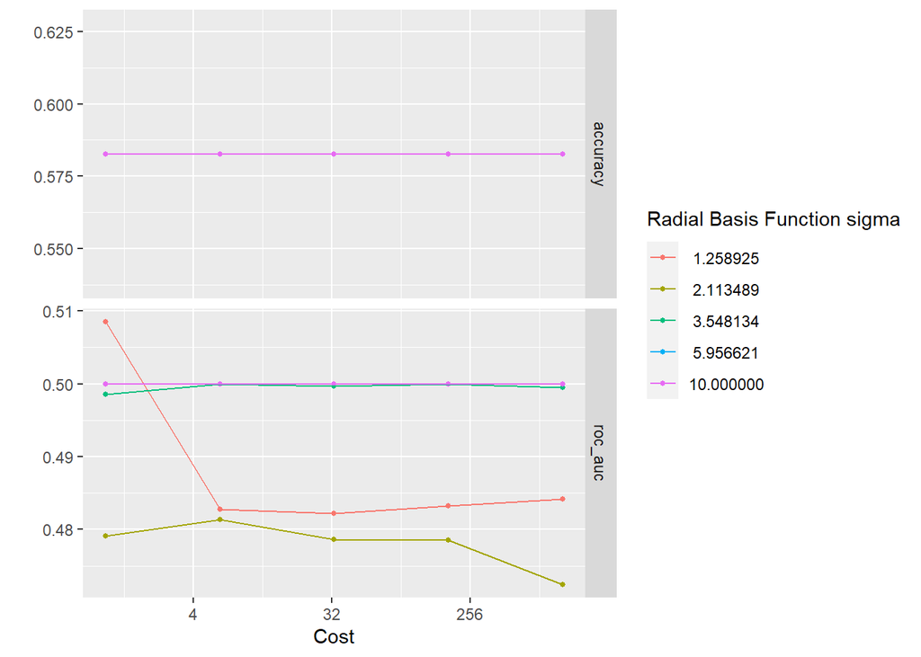

```r
load("UFC_SVM_Fit.rda")
autoplot(UFC_SVM_Fit)
```

## 4.3 Linear Discriminant Analysis

A Linear Discriminant Analysis model (LDA) is similar to a Quadratic Discriminant Analaysis (QDA) except fo rthe fact that it assumes that the covariance matrix is the same for all classes. The model also assumes that the predictors are normally distributed, which is might be true due to the size of the training set.

```r
UFC_LDA_Spec <- discrim_linear() %>%
  set_engine("MASS")

UFC_LDA_Workflow <- workflow() %>%
  add_model(UFC_LDA_Spec) %>%
  add_recipe(UFC_Recipe)
```

```r
UFC_LDA_Fit <- tune_grid(
  UFC_LDA_Workflow,
  resamples = UFC_Folds,
)

save(UFC_LDA_Fit, file = "UFC_LDA_Fit.rda")
```

We have no hyperparameters to tune for this model since it is fairly simple so we did not create a tuning grid.

```r
load("UFC_LDA_Fit.rda")
#autoplot(UFC_LDA_Fit)
```

## 4.4 Random Forest

This is where we begin to get into more complicated models. Logistic, SVM, and LDA were all rather simple to understand and interpret however Random Forest models are used for hteir predictive power and not their interpretability. A Random Forest model is based off of multiple decision trees. Decision trees find the best split and continue on from there and random forests take multiple trees (which is a parameter) and uses a method to group them together.

```r
#RANDOM FOREST MODEL
UFC_RF_Spec <- rand_forest(mtry = tune(), trees = tune(), min_n = tune()) %>%
  set_engine("ranger", importance = 'impurity') %>%
  set_mode("classification")

UFC_RF_Workflow <- workflow() %>%
  add_recipe(UFC_Recipe) %>%
  add_model(UFC_RF_Spec)

UFC_RF_Tune <- grid_regular(
  mtry(range = c(2, 8)),
  min_n(range = c(2, 10)),
  trees(range = c(100, 2000)),
  levels = 5
)
```

```r
UFC_RF_Fit <- tune_grid(
  UFC_RF_Workflow,
  resamples = UFC_Folds,
  grid = UFC_RF_Tune,
)
save(UFC_RF_Fit, file = "UFC_RF_Fit.rda")

#Best parameters are mtry = 2, trees = 575, and min_n = 4. ROC_AUC of 0.7049678
```

There are multiple parameters to be tuned in Random Forests which is another feature that helps its predictive accuracy. However, the multitude of parameters leads to a very high processing time for this model which is arguably its biggest drawback. “trees” is the parameter that decides how many decision trees will be used to create the “Forest”. “mtry” is the parameter that determines how many variables to consider at each split of the decision tree. And min_n is the minimum number of samples to create a split for the decision tree.

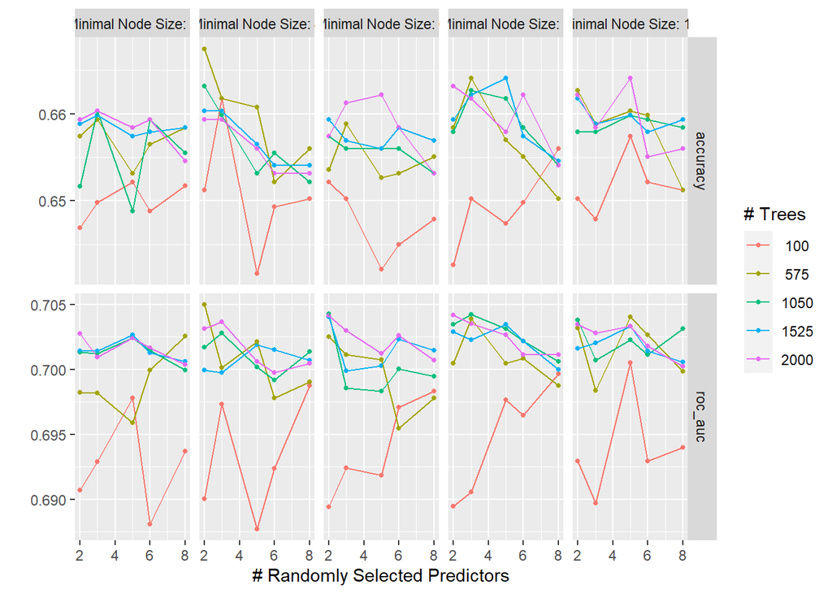

```r
load("UFC_RF_Fit.rda")
autoplot(UFC_RF_Fit)
```

## 4.5 Boosted Tree

Boosted Tree models, similar to Random Forests, are known for their predictive prowess and not their interpretability. Again, similar to Random Forests, they are based off of decision trees. However, the difference between the two is that the random forest lets each decision do what it wants and then combines them at the end using the specified method while boosted trees work sequentially. Each decision tree works to correct the minor errors of the tree before it.

```r
UFC_BT_Spec <- boost_tree(learn_rate = tune(), tree_depth = tune(), trees = tune()) %>%
  set_engine("xgboost") %>%
  set_mode("classification")
UFC_BT_Workflow <- workflow() %>%
  add_recipe(UFC_Recipe) %>%
  add_model(UFC_BT_Spec)

UFC_BT_Tune <- grid_regular(
  learn_rate(range = c(0.01, 0.3)),
  tree_depth(range = c(1, 10)),
  trees(range = c(50, 200)),
  levels = 5
)
```

```r
UFC_BT_Fit <- tune_grid(
  UFC_BT_Workflow,
  resamples = UFC_Folds,
  grid = UFC_BT_Tune,
)
save(UFC_BT_Fit, file = "UFC_BT_Fit.rda")
```

The Boosted tree model also has many hyperparameters that are ready to be tuned. It shares parameters like tree_depth and tree with Random Forest models. Learn_rate is a parameter that determines how quickly the machines learns new information. If this number is set high it could be subject to overfitting since each individiual piece of data is highly regarded rather than the overall grand scheme of things.

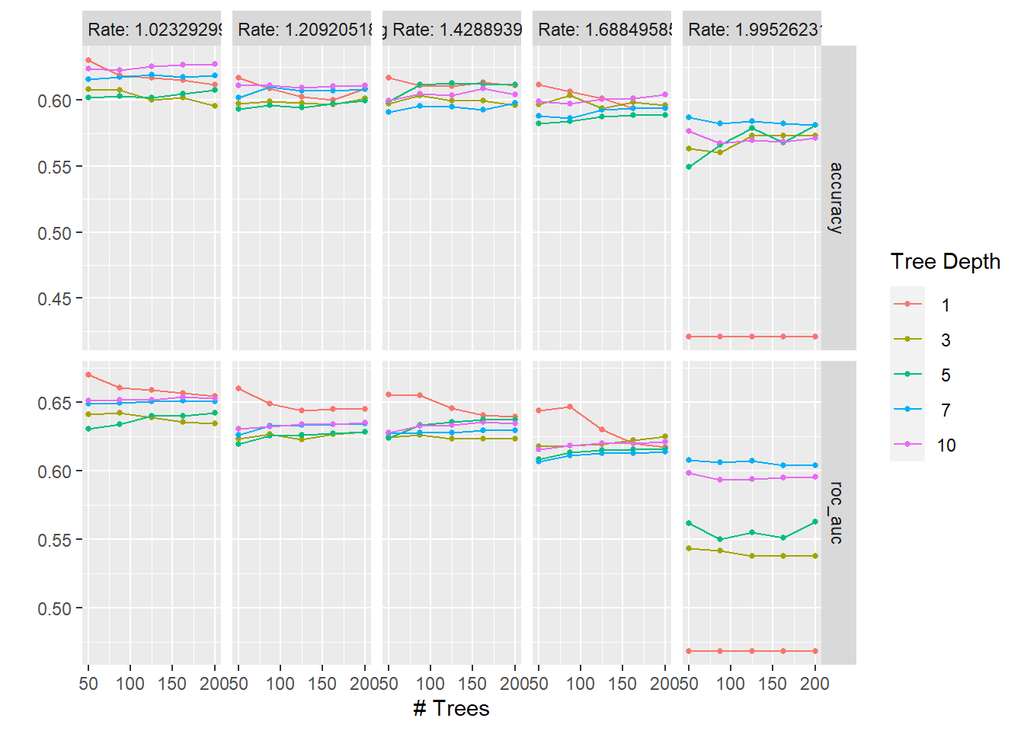

```r
load("UFC_BT_Fit.rda")
autoplot(UFC_BT_Fit)
```

## 4.6 Neural Network

A Neural Netowkr Model is largely based off of how the human brain works. There are nodes that are organized in layers which the data goes through. There is the input layer, hidden layers, and the output layer. all the nodes have weights and biases and an activation function. These models are the ones that are used in processes like facial and image recognition since they do well with non data inputs like images and video.

```r
#Note to grader. I was not able to get tensorflow to download on my laptop however I am certain this is the correct code for a neural network model. Run it on your laptop which hopefully has the correct programs downloaded. However, for the rest of this project I will no longer be considering this model since I am not able to collect metrics on it. I left it here because I worked too hard on it just to delete it. I would greatly appreciate it if I can get an email back telling me how accurate this model is, thank you.
UFC_NN_Spec <- mlp(mode = "classification", hidden_units = tune(), penalty = tune(), epochs = tune()) %>%
  set_engine("keras")
UFC_NN_Workflow <- workflow() %>%
  add_model(UFC_NN_Spec) %>%
  add_recipe(UFC_Recipe)
UFC_NN_Tune <- grid_regular(
  hidden_units(range = c(10, 100)),
  penalty(range = c(0, 1)),
  epochs(range = c(50, 500)),
  levels = 5
)


UFC_NN_Fit <- tune_grid(
  UFC_NN_Workflow,
  resamples = UFC_Folds,
  grid = UFC_NN_Tune,
  )
save(UFC_NN_Fit, file = "UFC_NN_Fit.rda")
```

The Neural Network model has three parameters, hidden_units which determines number of hidden layers, penalty which has to do with the regularization technique applied to the model, and epochs which is the number of complete forward and backward passes that the learning algorithm goes through the dataset.

```r
#load("UFC_NN_Fit.rda")
#autoplot(UFC_NN_Fit)
```

In order to find the best model we use collect_metrics to find the ROC_AUC value that is the highest among all the iterations of all the models.

```r
arrange(filter(collect_metrics(UFC_Logistic_Fit), .metric == "roc_auc"), desc(mean))
```

```
## # A tibble: 25 × 8
##    penalty mixture .metric .estimator  mean     n std_err .config
##      <dbl>   <dbl> <chr>   <chr>      <dbl> <int>   <dbl> <chr>
##  1    1.78   0.05  roc_auc binary     0.694     5 0.00858 Preprocessor1_Model02
##  2    1.00   0.05  roc_auc binary     0.694     5 0.00870 Preprocessor1_Model01
##  3    3.17   0.05  roc_auc binary     0.649     5 0.0374  Preprocessor1_Model03
##  4    5.63   0.05  roc_auc binary     0.5       5 0       Preprocessor1_Model04
##  5   10      0.05  roc_auc binary     0.5       5 0       Preprocessor1_Model05
##  6    1.00   0.288 roc_auc binary     0.5       5 0       Preprocessor1_Model06
##  7    1.78   0.288 roc_auc binary     0.5       5 0       Preprocessor1_Model07
##  8    3.17   0.288 roc_auc binary     0.5       5 0       Preprocessor1_Model08
##  9    5.63   0.288 roc_auc binary     0.5       5 0       Preprocessor1_Model09
## 10   10      0.288 roc_auc binary     0.5       5 0       Preprocessor1_Model10
## # ℹ 15 more rows
```

```r
arrange(filter(collect_metrics(UFC_SVM_Fit), .metric == "roc_auc"), desc(mean))
```

[output not shown]

```r
arrange(filter(collect_metrics(UFC_LDA_Fit), .metric == "roc_auc"), desc(mean))
```

```
## # A tibble: 1 × 6
##   .metric .estimator  mean     n std_err .config
##   <chr>   <chr>      <dbl> <int>   <dbl> <chr>
## 1 roc_auc binary     0.688     1      NA Preprocessor1_Model1
```

```r
arrange(filter(collect_metrics(UFC_RF_Fit), .metric == "roc_auc"), desc(mean))
```

[output not shown]

```r
arrange(filter(collect_metrics(UFC_BT_Fit), .metric == "roc_auc"), desc(mean))
```

```
## # A tibble: 125 × 9
##    trees tree_depth learn_rate .metric .estimator  mean     n std_err .config
##    <int>      <int>      <dbl> <chr>   <chr>      <dbl> <int>   <dbl> <chr>
##  1    50          1       1.02 roc_auc binary     0.670     5 0.00894 Preproces…
##  2    87          1       1.02 roc_auc binary     0.660     5 0.00786 Preproces…
##  3    50          1       1.21 roc_auc binary     0.660     5 0.0116  Preproces…
##  4   125          1       1.02 roc_auc binary     0.659     5 0.00851 Preproces…
##  5   162          1       1.02 roc_auc binary     0.657     5 0.00830 Preproces…
##  6    50          1       1.43 roc_auc binary     0.655     5 0.0105  Preproces…
##  7    87          1       1.43 roc_auc binary     0.655     5 0.00859 Preproces…
##  8   200          1       1.02 roc_auc binary     0.655     5 0.00784 Preproces…
##  9   162         10       1.02 roc_auc binary     0.654     5 0.0114  Preproces…
## 10   200         10       1.02 roc_auc binary     0.653     5 0.0115  Preproces…
## # ℹ 115 more rows
```

```r
#arrange(filter(collect_metrics(UFC_NN_Fit), .metric == "roc_auc"), mean)
```

```r
Best_Model <- select_best(UFC_BT_Fit)
Best_Workflow <- finalize_workflow(UFC_BT_Workflow, Best_Model)
Best_Fit <- fit(Best_Workflow, UFC_Train)
```

# 5 Testing

```r
The_Test <- augment(Best_Fit, UFC_Test)
The_Test$Winner <- as.factor(The_Test$Winner)
The_Results <- roc_auc(The_Test, truth = Winner, .pred_Blue)
The_Results
```

```
## # A tibble: 1 × 3
##   .metric .estimator .estimate
##   <chr>   <chr>          <dbl>
## 1 roc_auc binary         0.684
```

# 6 Conclusion